# TumorSamplesGraphNoTSPY1Gene

Annika Jorgensen

2023-11-01

## **Purpose**

This Rmarkdown will plot FPKM expression of DDX3Y, EIF1AY, TXLNGY, KDM5D separated by male tumor samples. This is a second iteration of XdegeneratFPKMespression.Rmd where tumor samples FPKM expression were plotted but not separated by sex and the gene TSPY1 was added. Sex is separated out because these genes are y-linked. TSPY1 is not included because there is no expression in most samples

## **Results**

Two graphs were created. The first showed the gene expression of all samples with expression under **100 FPKM**. The second showed the gene expression of all samples with expression under **500 FPKM**.

**Read in data** Reading in a .csv file created in the XdegenerateFPKMexpression.Rmd file which contains the tumor expression data of the four genes

```r
#reading in tumor expression data for DDX3Y, EIF1AY, TXLNGY, KDM5D, TSPY1
Tumor_expressionData <- read.csv("~/Desktop/ResearchProjects/LiverCancer/DEA_removed_samples/GeneExpressionPlots/data/TumorExpressionData5genes.csv",row.names=1,header=TRUE, sep=",")

#removing expression data for TSPY1
Tumor_expressionData<- Tumor_expressionData[-5,]

#creating a vector for the x axis of our plot
geneXaxis<- 1:4
```

**Tumor male samples data frame** This code chunk will iteratively create a data frame with all male samples that have FPKM under 100 FPKM in all genes

```r
#creating data frame with sample 3 expression data
dataFiltered<-  as.data.frame(cbind(genes=rownames(Tumor_expressionData),Expression=Tumor_expressionData[,2],Names=c("003","003","003","003")))
rownames(dataFiltered)<-1:4

#creating data frame with sample 202 expression
newRow<- as.data.frame(cbind(genes=rownames(Tumor_expressionData),Expression=Tumor_expressionData[,115],Names=c("207","207","207","207")))
rownames(newRow)<-1:4

#combining sample 202 and sample 3
dataFiltered<- rbind(dataFiltered,newRow)
```

Plotting all samples with FPKM under 100 FPKM in all genes

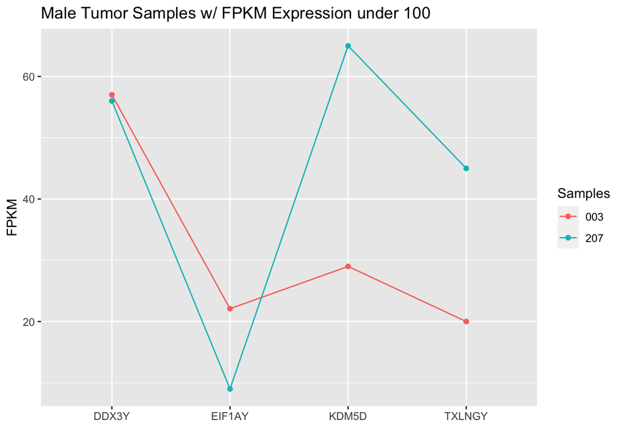

```r
#changing Expression values to be numeric
dataFiltered$Expression<- as.numeric(dataFiltered$Expression)

#plotting all samples with FPKM under 100
expressionPlot<- ggplot(data=dataFiltered, aes(x=genes,y=Expression,group=Names)) +  geom_line(aes(color=Names))+
  geom_point(aes(color=Names))+ ggtitle("Male Tumor Samples w/ FPKM Expression under 100") + ylab("FPKM") +xlab("")+ labs(color = "Samples")
expressionPlot
```

```r
#outputting plot to PDF
pdf("~/Desktop/ResearchProjects/LiverCancer/DEA_removed_samples/newFigures/FPKM_sampleNamesPlots/MalesSamples_100FPKM_GeneExpressionPlot.pdf", width=12, height=12)
expressionPlot<- ggplot(data=dataFiltered, aes(x=genes,y=Expression,group=Names)) +  geom_line(aes(color=Names))+
  geom_point(aes(color=Names))+ ggtitle("Male Tumor Samples w/ FPKM Expression under 100 FPKM") + ylab("FPKM") +xlab("")+ labs(color = "Samples")
expressionPlot
dev.off()
```

Making a data frame with all male tumor samples

```r
Tumor_expressionData<- t(Tumor_expressionData)
Tumor_expressionData<- as.data.frame(Tumor_expressionData)

MaleTumor_expressionData<- Tumor_expressionData[grepl("XY",rownames(Tumor_expressionData),fixed=TRUE),]
MaleTumor_expressionData<- t(MaleTumor_expressionData)
MaleTumor_expressionData<-as.data.frame(MaleTumor_expressionData)

Tumor_expressionData<- t(Tumor_expressionData)
Tumor_expressionData<- as.data.frame(Tumor_expressionData)
```

This code chunk will iteratively create a data frame with all male samples that have FPKM under 500FPKM in all genes

```r
#creating data frame with sample 3 expression data
dataFiltered<-  as.data.frame(cbind(genes=rownames(MaleTumor_expressionData),Expression=MaleTumor_expressionData[,2],Names=c("003","003","003","003")))
rownames(dataFiltered)<-1:4

#creating data frame with sample 034 expression
newRow<- as.data.frame(cbind(genes=rownames(MaleTumor_expressionData),Expression=MaleTumor_expressionData[,17],Names=c("034","034","034","034")))
rownames(newRow)<-1:4

#combining sample 034 and sample 3
dataFiltered<- rbind(dataFiltered,newRow)

#creating data frame with sample 060 expression
newRow<- as.data.frame(cbind(genes=rownames(MaleTumor_expressionData),Expression=MaleTumor_expressionData[,34],Names=c("060","060","060","060")))
rownames(newRow)<-1:4

#combining sample 060 and sample 3,034
dataFiltered<- rbind(dataFiltered,newRow)

#creating data frame with sample 088 expression
newRow<- as.data.frame(cbind(genes=rownames(MaleTumor_expressionData),Expression=MaleTumor_expressionData[,42],Names=c("088","088","088","088")))
rownames(newRow)<-1:4

#combining sample 088 and sample 3,034,060
dataFiltered<- rbind(dataFiltered,newRow)

#creating data frame with sample 120 expression
newRow<- as.data.frame(cbind(genes=rownames(MaleTumor_expressionData),Expression=MaleTumor_expressionData[,52],Names=c("120","120","120","120")))
rownames(newRow)<-1:4

#combining sample 120 and sample 3,034,060,088
dataFiltered<- rbind(dataFiltered,newRow)

#creating data frame with sample 162 expression
newRow<- as.data.frame(cbind(genes=rownames(MaleTumor_expressionData),Expression=MaleTumor_expressionData[,71],Names=c("162","162","162","162")))
rownames(newRow)<-1:4

#combining sample 162 and sample 3,034,060,088,120
dataFiltered<- rbind(dataFiltered,newRow)

#creating data frame with sample 175 expression
newRow<- as.data.frame(cbind(genes=rownames(MaleTumor_expressionData),Expression=MaleTumor_expressionData[,75],Names=c("175","175","175","175")))
rownames(newRow)<-1:4

#combining sample 175 and sample 3,034,060,088,120,162
dataFiltered<- rbind(dataFiltered,newRow)

#creating data frame with sample 181 expression
newRow<- as.data.frame(cbind(genes=rownames(MaleTumor_expressionData),Expression=MaleTumor_expressionData[,77],Names=c("181","181","181","181")))
rownames(newRow)<-1:4

#combining sample 181 and sample 3,034,060,088,120,162,175
dataFiltered<- rbind(dataFiltered,newRow)

#creating data frame with sample 207 expression
newRow<- as.data.frame(cbind(genes=rownames(MaleTumor_expressionData),Expression=MaleTumor_expressionData[,84],Names=c("207","207","207","207")))
rownames(newRow)<-1:4

#combining sample 207 and sample 3,034,060,088,120,162,175,181
dataFiltered<- rbind(dataFiltered,newRow)

#creating data frame with sample 262 expression
newRow<- as.data.frame(cbind(genes=rownames(MaleTumor_expressionData),Expression=MaleTumor_expressionData[,100],Names=c("262","262","262","262")))
rownames(newRow)<-1:4

#combining sample 262 and sample 3,034,060,088,120,162,175,181,207
dataFiltered<- rbind(dataFiltered,newRow)

#creating data frame with sample 263 expression
newRow<- as.data.frame(cbind(genes=rownames(MaleTumor_expressionData),Expression=MaleTumor_expressionData[,101],Names=c("263","263","263","263")))
rownames(newRow)<-1:4

#combining sample 263 and sample 3,034,060,088,120,162,175,181,207,262
dataFiltered<- rbind(dataFiltered,newRow)
```

Plotting all samples with expression under 500 FPKM in all genes

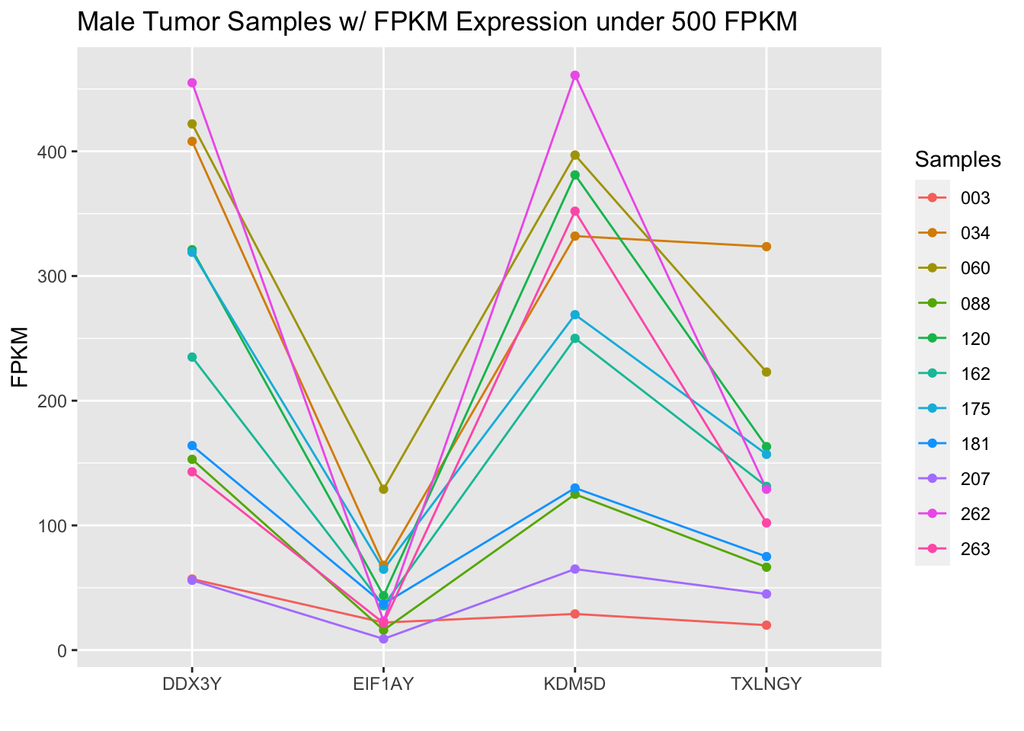

```r
#changing Expression values to be numeric
dataFiltered$Expression<- as.numeric(dataFiltered$Expression)

#plotting all samples with FPKM under 500
expressionPlot<- ggplot(data=dataFiltered, aes(x=genes,y=Expression,group=Names)) +  geom_line(aes(color=Names))+
  geom_point(aes(color=Names)) + ggtitle("Male Tumor Samples w/ FPKM Expression under 500 FPKM") + ylab("FPKM") +xlab("")+ labs(color = "Samples")
expressionPlot
```

```r
#outputting plot to PDF
pdf("~/Desktop/ResearchProjects/LiverCancer/DEA_removed_samples/newFigures/FPKM_sampleNamesPlots/MalesSamples_500FPKM_GeneExpressionPlot.pdf", width=12, height=12)

#plotting all samples with FPKM under 500
expressionPlot<- ggplot(data=dataFiltered, aes(x=genes,y=Expression,group=Names)) +  geom_line(aes(color=Names))+
  geom_point(aes(color=Names)) + ggtitle("Male Tumor Samples w/ FPKM Expression under 500 FPKM") + ylab("FPKM") +xlab("")+ labs(color = "Samples")
expressionPlot
dev.off()
```